# Salary Predictions Based on Job Descriptions

# Part 1 - DEFINE

### ---- 1 Define the problem ----

#### **This is a simple project, where we will try to solve a business problem related to HR.**

We want to use Machine learning technology and develop a model that predicts the salary when years of work experience , job type, Majors, industry type, degree and miles from metropolis is given.

This data talks about different features, attributes which are helpful to understand the relatve salary for a particular Job. Now if we can somehow predict the correct salaries for any given job type, based on some specific and common Attributes, it can be a great help for the HR team in Recruiting new resources.

Hence, as per the tradition machine learning approach, we have the labeled dataset which tells us what salary is most offered for a job, and using that we can build a generalised model which can predict.

**The features in this data set are described as below:**

**Years Experience:** Total Years of experience

**Job Type:** The position held (CEO, CFO, CTO, Vice President, Manager, Janitor, junior and senior)

**College Degree:** Doctoral, Masters, Bachelors, High School, or None

**College Major:** Computer Science, Engineering, Literature , Biology, Business, Chemistry, Math, Physics

**Miles From Metropolis:** How far is the Person staying from City Center.

**Author** = **"Vijay Kumar Yadav"**  
**E-Mail** = **"vjyadav193@gmail.com"**

```python
## Load all the Important Libraries.

import pandas as pd
import sklearn as sk
import numpy as np
import seaborn as sns
import matplotlib.pyplot as plt
%matplotlib inline
import warnings
warnings.filterwarnings('ignore')

from scipy.stats import norm
from sklearn.model_selection import train_test_split
from sklearn.model_selection import cross_val_score
from sklearn.model_selection import cross_val_predict
from sklearn.model_selection import GridSearchCV
from sklearn.model_selection import StratifiedKFold
from sklearn.metrics import mean_squared_error
from sklearn.linear_model import LinearRegression
from sklearn.linear_model import Ridge
from sklearn.preprocessing import PolynomialFeatures
from sklearn.preprocessing import StandardScaler
from sklearn.ensemble import RandomForestRegressor
from sklearn.pipeline import Pipeline
from sklearn.externals import joblib
```

## Create Fucntions for all the Repeatative work , to organise and do things faster.

```python
### Fuction to Load Data in Pandas Datafram.

def load_file(file):
    df =  pd.read_csv(file)
    shape = df.shape
    print("Data Is loaded, and the shape os dataset is {} ".format(shape))
    return df

#clean the data - remove duplicates and salaries that are $0
def clean_data(original_df):
    clean_data = original_df.drop_duplicates(subset='jobId')
    clean_data = original_df[original_df.salary>0]
    return clean_data

#scatter plots
def scatter_data(df, col):
    plt.figure(figsize = (12,8))
    plt.scatter(df[col], df['salary'] )
    plt.ylabel('salary')
    plt.xlabel(col)

#regression plots
def reg_data(df, col):
    plt.figure(figsize=(12,8))
    sns.regplot(x=df[col], y = df['salary'], data = df, line_kws = {'color' : 'red'})
    plt.ylim(0,)

#residual plots
def res_data(df,col):
    plt.figure(figsize=(12,8))
    sns.residplot(x=df[col], y = df['salary'], data = df)
    plt.show()

#distribution plots
def dis_data(Rfunction, Bfunction, Rname, Bname, title):
    plt.figure(figsize=(10,6))
    ax1 = sns.distplot(Rfunction, hist = False, color = 'r', label = Rname)
    ax1 = sns.distplot(Bfunction, hist = False, color = 'b', label = Bname)
    plt.title(title)
    plt.show()
    plt.close()
```

## Part 2 - DISCOVER

### Load the Data

```python
#load data
print("Loading data..")
train_feat_df = load_file('D:/Vijay_Personal_docs/Vijay/DSDJ/DSDJ-data-SalaryPredictions/data/train_features.csv')
train_target_df = load_file('D:\Vijay_Personal_docs\Vijay\DSDJ\DSDJ-data-SalaryPredictions\data/train_salaries.csv')
test_feat_df = load_file('D:\Vijay_Personal_docs\Vijay\DSDJ\DSDJ-data-SalaryPredictions\data/test_features.csv')


print("Loading data Successfully completed.")

#define the variables
cat_vars = ['companyId', 'jobType', 'degree', 'major', 'industry']
num_vars = ['yearsExperience', 'milesFromMetropolis']
tar = 'salary'

#verify data is laoded
train_feat_df.head()
```

```
Loading data..
Data Is loaded, and the shape os dataset is (1000000, 8)
Data Is loaded, and the shape os dataset is (1000000, 2)
Data Is loaded, and the shape os dataset is (1000000, 8)
Loading data Successfully completed.
```

|  | jobId | companyId | jobType | degree | major | industry | yearsExperience | milesFromMetropolis |
| --- | --- | --- | --- | --- | --- | --- | --- | --- |
| 0 | JOB1362684407687 | COMP37 | CFO | MASTERS | MATH | HEALTH | 10 | 83 |
| 1 | JOB1362684407688 | COMP19 | CEO | HIGH_SCHOOL | NONE | WEB | 3 | 73 |
| 2 | JOB1362684407689 | COMP52 | VICE_PRESIDENT | DOCTORAL | PHYSICS | HEALTH | 10 | 38 |
| 3 | JOB1362684407690 | COMP38 | MANAGER | DOCTORAL | CHEMISTRY | AUTO | 8 | 17 |
| 4 | JOB1362684407691 | COMP7 | VICE_PRESIDENT | BACHELORS | PHYSICS | FINANCE | 8 | 16 |

```python
train_feat_df.head()
```

|  | jobId | companyId | jobType | degree | major | industry | yearsExperience | milesFromMetropolis |
| --- | --- | --- | --- | --- | --- | --- | --- | --- |
| 0 | JOB1362684407687 | COMP37 | CFO | MASTERS | MATH | HEALTH | 10 | 83 |
| 1 | JOB1362684407688 | COMP19 | CEO | HIGH_SCHOOL | NONE | WEB | 3 | 73 |
| 2 | JOB1362684407689 | COMP52 | VICE_PRESIDENT | DOCTORAL | PHYSICS | HEALTH | 10 | 38 |
| 3 | JOB1362684407690 | COMP38 | MANAGER | DOCTORAL | CHEMISTRY | AUTO | 8 | 17 |
| 4 | JOB1362684407691 | COMP7 | VICE_PRESIDENT | BACHELORS | PHYSICS | FINANCE | 8 | 16 |

#### Just peek into the data , and have a look wheater all the data has been imported properly

```python
train_feat_df.dtypes
```

```python
train_feat_df.info()
```

```
<class 'pandas.core.frame.DataFrame'>
RangeIndex: 1000000 entries, 0 to 999999
Data columns (total 8 columns):
jobId                  1000000 non-null object
companyId              1000000 non-null object
jobType                1000000 non-null object
degree                 1000000 non-null object
major                  1000000 non-null object
industry               1000000 non-null object
yearsExperience        1000000 non-null int64
milesFromMetropolis    1000000 non-null int64
dtypes: int64(2), object(6)
memory usage: 61.0+ MB
```

```python
train_target_df.info()
```

```
<class 'pandas.core.frame.DataFrame'>
RangeIndex: 1000000 entries, 0 to 999999
Data columns (total 2 columns):
jobId     1000000 non-null object
salary    1000000 non-null int64
dtypes: int64(1), object(1)
memory usage: 15.3+ MB
```

```python
test_feat_df.info()
```

```
<class 'pandas.core.frame.DataFrame'>
RangeIndex: 1000000 entries, 0 to 999999
Data columns (total 8 columns):
jobId                  1000000 non-null object
companyId              1000000 non-null object
jobType                1000000 non-null object
degree                 1000000 non-null object
major                  1000000 non-null object
industry               1000000 non-null object
yearsExperience        1000000 non-null int64
milesFromMetropolis    1000000 non-null int64
dtypes: int64(2), object(6)
memory usage: 61.0+ MB
```

### Merge the Target feature and Training features for modeling

```python
train_df = pd.merge(train_feat_df,train_target_df, on = 'jobId')
```

```python
train_df.shape
```

```
(1000000, 9)
```

```python
## missing values / DUplicate values
print("There are {} duplicate values in the Given Dataset".format(train_df.duplicated().sum()))

print("List of missing Values:- {}".format(train_df.isna().sum()))
```

```
There are 0 duplicate values in the Given Dataset
List of missing Values:- jobId                  0
companyId              0
jobType                0
degree                 0
major                  0
industry               0
yearsExperience        0
milesFromMetropolis    0
salary                 0
dtype: int64
```

```python
## summarize the Numerical Columns to get the idea of range and distribution of the Salary
train_feat_df.describe(include = [np.number])
```

|  | yearsExperience | milesFromMetropolis |
| --- | --- | --- |
| count | 1000000.000000 | 1000000.000000 |
| mean | 11.992386 | 49.529260 |
| std | 7.212391 | 28.877733 |
| min | 0.000000 | 0.000000 |
| 25% | 6.000000 | 25.000000 |
| 50% | 12.000000 | 50.000000 |
| 75% | 18.000000 | 75.000000 |
| max | 24.000000 | 99.000000 |

```python
# have a look at the information of the Categorical Data
train_feat_df.describe(include = ['O'])
```

|  | jobId | companyId | jobType | degree | major | industry |
| --- | --- | --- | --- | --- | --- | --- |
| count | 1000000 | 1000000 | 1000000 | 1000000 | 1000000 | 1000000 |
| unique | 1000000 | 63 | 8 | 5 | 9 | 7 |
| top | JOB1362684742801 | COMP39 | SENIOR | HIGH_SCHOOL | NONE | WEB |
| freq | 1 | 16193 | 125886 | 236976 | 532355 | 143206 |

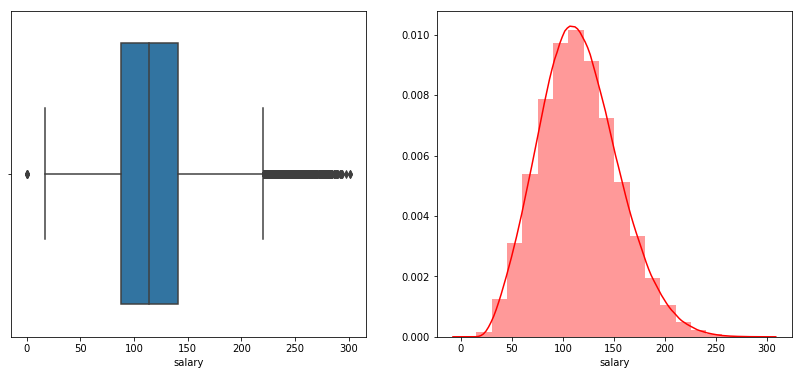

```python
# Visualize target variable (salary)
plt.figure(figsize = (14, 6))
plt.subplot(1,2,1)
sns.boxplot(train_df.salary)
plt.subplot(1,2,2)
sns.distplot(train_df.salary, bins=20 , color = 'red')
plt.show()
```

Here, we see that the Salary column does have a symetrical looking distribution , which is a sign of good dataset. Altough we see, certain potential outlier and we can remove them .

```python
## To understand the Upper limit, lower limit of the range of your target vcariable, we can use IQR rule.

stat = train_df.salary.describe()
print(stat)
IQR = stat['75%'] - stat['25%']
upper = stat['75%'] + 1.5 * IQR
lower = stat['25%'] - 1.5 * IQR
print('The upper and lower bounds for suspected outliers are {} and {}.'.format(upper, lower))
```

```
count    1000000.000000
mean         116.061818
std           38.717936
min            0.000000
25%           88.000000
50%          114.000000
75%          141.000000
max          301.000000
Name: salary, dtype: float64
The upper and lower bounds for suspected outliers are 220.5 and 8.5.
```

#### Now we see, that maximum salary in our data set is of **"301$"**

#### and minimum salary in our data set is of **"0$"**

```python
#### Now we understand from our intution that, no one can have " 0 " salary, hence lets go and further Examine them,

train_df[train_df.salary < 8.5]
```

|  | jobId | companyId | jobType | degree | major | industry | yearsExperience | milesFromMetropolis | salary |
| --- | --- | --- | --- | --- | --- | --- | --- | --- | --- |
| 30559 | JOB1362684438246 | COMP44 | JUNIOR | DOCTORAL | MATH | AUTO | 11 | 7 | 0 |
| 495984 | JOB1362684903671 | COMP34 | JUNIOR | NONE | NONE | OIL | 1 | 25 | 0 |
| 652076 | JOB1362685059763 | COMP25 | CTO | HIGH_SCHOOL | NONE | AUTO | 6 | 60 | 0 |
| 816129 | JOB1362685223816 | COMP42 | MANAGER | DOCTORAL | ENGINEERING | FINANCE | 18 | 6 | 0 |
| 828156 | JOB1362685235843 | COMP40 | VICE_PRESIDENT | MASTERS | ENGINEERING | WEB | 3 | 29 | 0 |

### ---- 3 Clean the data ----

#### look for duplicate data, invalid data (e.g. salaries <=0), or corrupt data and remove it

```python
#check potential outlier above upper bound
train_df.loc[train_df.salary > 222.5, 'jobType'].value_counts()
```

```
CEO               2893
CFO               1308
CTO               1298
VICE_PRESIDENT     520
MANAGER            188
SENIOR              50
JUNIOR              16
Name: jobType, dtype: int64
```

```python
# In Uppper bound also we can check for potential outliers .

up_outliers = train_df[(train_df.salary > 222.5) & (train_df.jobType == 'JUNIOR')]
up_outliers.head()
```

|  | jobId | companyId | jobType | degree | major | industry | yearsExperience | milesFromMetropolis | salary |
| --- | --- | --- | --- | --- | --- | --- | --- | --- | --- |
| 1222 | JOB1362684408909 | COMP40 | JUNIOR | MASTERS | COMPSCI | OIL | 24 | 5 | 225 |
| 27710 | JOB1362684435397 | COMP21 | JUNIOR | DOCTORAL | ENGINEERING | OIL | 24 | 3 | 246 |
| 31355 | JOB1362684439042 | COMP45 | JUNIOR | DOCTORAL | COMPSCI | FINANCE | 24 | 0 | 225 |
| 100042 | JOB1362684507729 | COMP17 | JUNIOR | DOCTORAL | BUSINESS | FINANCE | 23 | 8 | 248 |
| 160333 | JOB1362684568020 | COMP18 | JUNIOR | DOCTORAL | BUSINESS | FINANCE | 22 | 3 | 223 |

```python
up_outliers.describe(include = 'O')
```

|  | jobId | companyId | jobType | degree | major | industry |
| --- | --- | --- | --- | --- | --- | --- |
| count | 16 | 16 | 16 | 16 | 16 | 16 |
| unique | 16 | 15 | 1 | 3 | 3 | 3 |
| top | JOB1362685195361 | COMP40 | JUNIOR | DOCTORAL | BUSINESS | OIL |
| freq | 1 | 2 | 16 | 11 | 7 | 9 |

```python
## Clean the Data set with the use of Clean Function.
train_df = clean_data(train_df)
```

```python
train_df.shape
```

```
(999995, 9)
```

```python
#Reset the index values after dropping the invalid values
train_df.reset_index(drop = True)
train_df.head()
```

|  | jobId | companyId | jobType | degree | major | industry | yearsExperience | milesFromMetropolis | salary |
| --- | --- | --- | --- | --- | --- | --- | --- | --- | --- |
| 0 | JOB1362684407687 | COMP37 | CFO | MASTERS | MATH | HEALTH | 10 | 83 | 130 |
| 1 | JOB1362684407688 | COMP19 | CEO | HIGH_SCHOOL | NONE | WEB | 3 | 73 | 101 |
| 2 | JOB1362684407689 | COMP52 | VICE_PRESIDENT | DOCTORAL | PHYSICS | HEALTH | 10 | 38 | 137 |
| 3 | JOB1362684407690 | COMP38 | MANAGER | DOCTORAL | CHEMISTRY | AUTO | 8 | 17 | 142 |
| 4 | JOB1362684407691 | COMP7 | VICE_PRESIDENT | BACHELORS | PHYSICS | FINANCE | 8 | 16 | 163 |

### ---- 4 Explore the data (EDA) ----

```python
#summarize each feature variable
#summarize the target variable
#look for correlation between each feature and the target
#look for correlation between features
```

```python
#count of unique values in categorical data
for cat in cat_vars:
    if cat != 'jobId' and cat != 'companyId':
       print(train_df[cat].value_counts())
```

```
SENIOR            125886
VICE_PRESIDENT    125234
MANAGER           125120
CTO               125045
JANITOR           124971
CEO               124778
JUNIOR            124592
CFO               124369
Name: jobType, dtype: int64
HIGH_SCHOOL    236975
NONE           236853
BACHELORS      175495
DOCTORAL       175362
MASTERS        175310
Name: degree, dtype: int64
NONE           532353
CHEMISTRY       58875
LITERATURE      58684
ENGINEERING     58594
BUSINESS        58518
PHYSICS         58410
COMPSCI         58382
BIOLOGY         58379
MATH            57800
Name: major, dtype: int64
WEB          143205
AUTO         142941
FINANCE      142866
EDUCATION    142819
OIL          142770
HEALTH       142755
SERVICE      142639
Name: industry, dtype: int64
```

```python
#compute the kurtosis and skewness of salary
print('Salary Skewness:', train_df['salary'].skew())
print('Salary Kurtosis:', train_df['salary'].kurt())
print('\n')
if -0.5 <= train_df['salary'].skew() <= 0.5:
    print('Salary distribution is approximately symmetric')
elif -0.5 > train_df['salary'] > 0.5:
    print('Salary distribution is skewed')
```

```
Salary Skewness: 0.34652727907668734
Salary Kurtosis: -0.025750772283374967


Salary distribution is approximately symmetric
```

### Visualize numerical data with salary

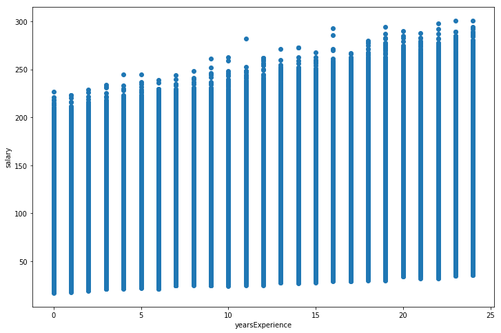

```python
scatter_data(train_df , 'yearsExperience')
```

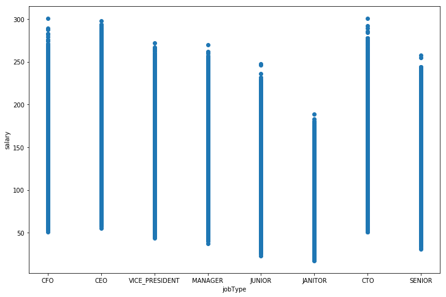

```python
scatter_data(train_df , 'jobType')
```

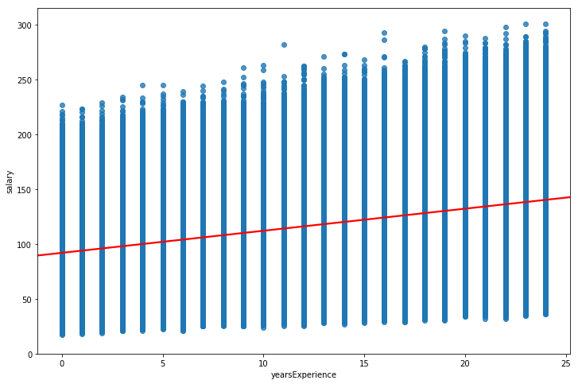

```python
reg_data(train_df, 'yearsExperience' )
```

### Lets visualize each feature with the target feature.

```python
def feature_plot(df,col):
    #Make subplots - left be the distribution of samples on the feature and right be the dependance of salary on the feature
    plt.figure(figsize=(12,8))
    plt.subplot(1,2,1)
    if df[col].dtype == 'int64':
        df[col].value_counts().sort_index().plot()
    else:
        #else change the categorical variable to category type and order their level by mean salary
        mean=df.groupby(col)['salary'].mean()
        df[col]=df[col].astype('category').copy()
        levels = mean.sort_values().index.to_list()
        df[col].cat.reorder_categories(levels, inplace = True)
        df[col].value_counts().plot()
    plt.xticks(rotation = 40)
    plt.xlabel(col)
    plt.ylabel('Counts')

    plt.subplot(1,2,2)
    if col == 'companyId':
        sns.boxplot(x=col, y = df['salary'], data = df)
        plt.xticks(rotation = 90)
    elif df[col].dtype == 'category':
        sns.violinplot(x = col, y = df['salary'], data = df, scale = 'count', inner = 'quartile')
        plt.xticks(rotation = 70)
    plt.ylabel('Salaries')
    plt.show()
```

```python
train_df.dtypes
```

```
jobId                  object
companyId              object
jobType                object
degree                 object
major                  object
industry               object
yearsExperience         int64
milesFromMetropolis     int64
salary                  int64
dtype: object
```

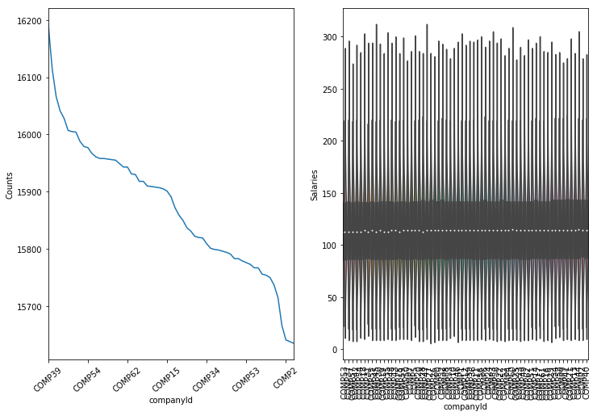

```python
feature_plot(train_df , 'companyId')
```

### This means there is no relation betweeen the the salaries , and Company ID

```python
train_df.columns
```

```
Index(['jobId', 'companyId', 'jobType', 'degree', 'major', 'industry',
       'yearsExperience', 'milesFromMetropolis', 'salary'],
      dtype='object')
```

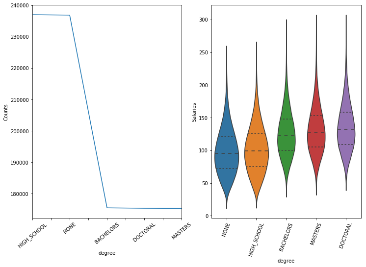

```python
feature_plot(train_df , 'degree')
```

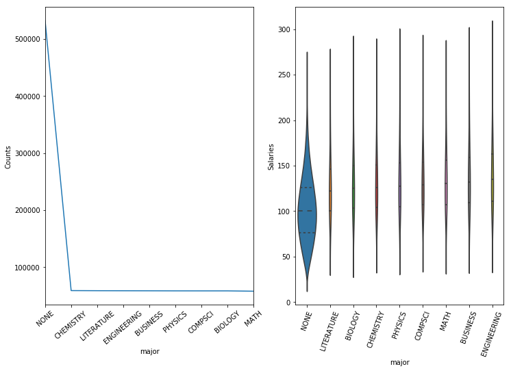

```python
feature_plot(train_df , 'major')
```

## here we can see that, people having he major in Engineering , business maths have mose lucurative salaries.

[figure not shown]

```python
plot_feature(train_df, 'yearsExperience')
```

### here there is clearly positive linearity in terms of relation between the Salary and Years of EXperience

[figure not shown]

```python
feature_plot(train_df, 'milesFromMetropolis')
```

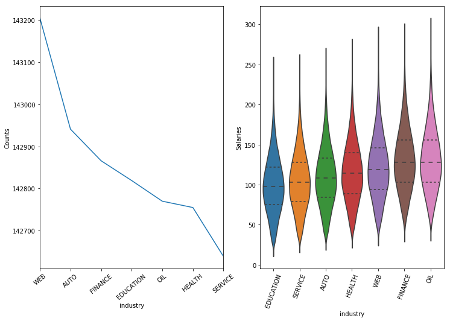

```python
feature_plot(train_df, 'industry')
```

### As per our intution , we know that OIL Finance and WEb are highest paying Jobs here.

Now we have to create corelations between the categorical values, for which we need to perfome one-hot encoding and create dummies , or lable encding usin encode method

```python
train_df.drop('jobId' , axis = 1 , inplace= True)
train_df.drop('companyId' , axis = 1 , inplace= True)
train_df.columns
```

```
Index(['jobType', 'degree', 'major', 'industry', 'yearsExperience',
       'milesFromMetropolis', 'salary'],
      dtype='object')
```

```python
train_df.head()
```

|  | jobType | degree | major | industry | yearsExperience | milesFromMetropolis | salary |
| --- | --- | --- | --- | --- | --- | --- | --- |
| 0 | CFO | MASTERS | MATH | HEALTH | 10 | 83 | 130 |
| 1 | CEO | HIGH_SCHOOL | NONE | WEB | 3 | 73 | 101 |
| 2 | VICE_PRESIDENT | DOCTORAL | PHYSICS | HEALTH | 10 | 38 | 137 |
| 3 | MANAGER | DOCTORAL | CHEMISTRY | AUTO | 8 | 17 | 142 |
| 4 | VICE_PRESIDENT | BACHELORS | PHYSICS | FINANCE | 8 | 16 | 163 |

## Convert categorical values into numerical values, so that we can use them for modeling purposes.

```python
# def encode_label(df, col):
#     #encode the categories using average salary for each category to replace label
#     cat_dict ={}
#     cats = df[col].cat.categories.tolist()
#     for cat in cats:
#         cat_dict[cat] = train_df[train_df[col] == cat]['salary'].mean()
#     df[col] = df[col].map(cat_dict)
```

```python
train_df.head()
```

[output not shown]

```python
# for col in train_df.columns:
#     if train_df[col].dtype.name == "category":
#         encode_label(train_df, col)
```

[figure not shown]

```python
# # Correlations between selected features and response
# # jobId is discarded because it is unique for individual
# fig = plt.figure(figsize=(12, 10))
# features = [ 'degree', 'major', 'industry', 'yearsExperience', 'milesFromMetropolis']
# sns.heatmap(train_df[features + ['salary']].corr(), cmap='BuPu', annot=True)
# plt.xticks(rotation=45)
# plt.show()
```

## One-Hot Encoding.

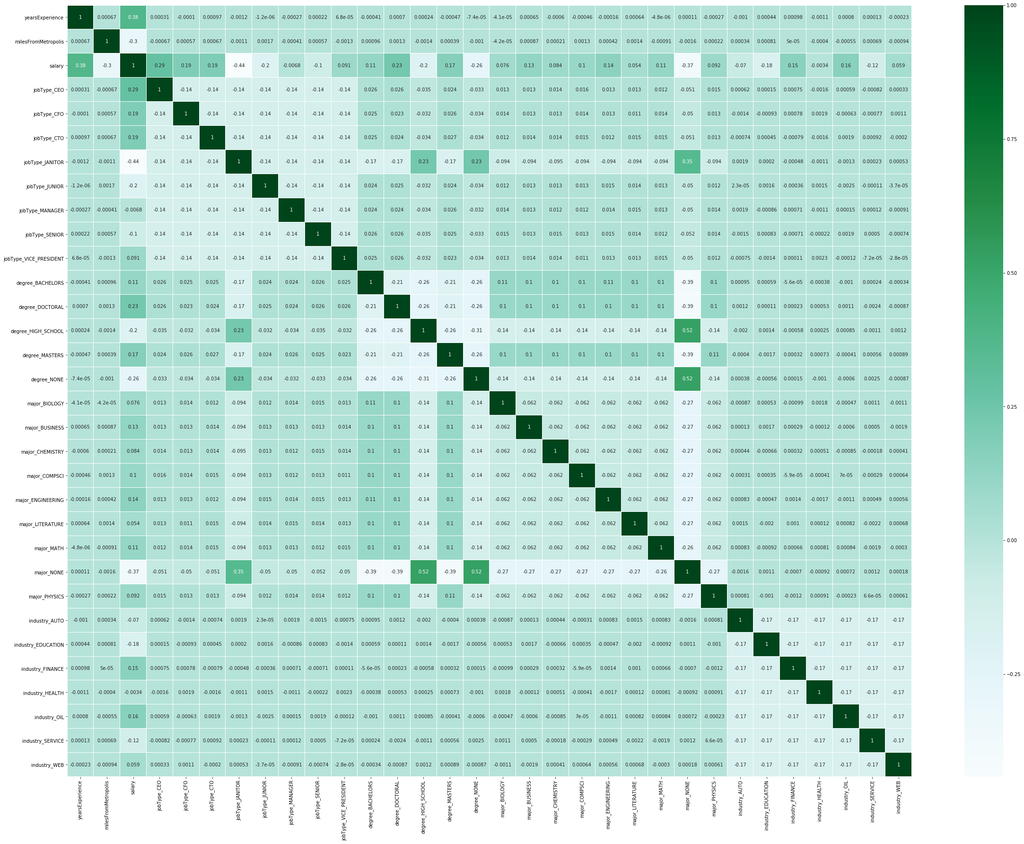

```python
## One-hot encode categorical data in clean_train_df dataset
train_df = pd.get_dummies(train_df)

# Plot heatmap of all data with correlation coefficients visible
train_df_corr = train_df.corr()
plt.subplots(figsize=(40,30))
sns.heatmap(train_df_corr, cmap = 'BuGn', linewidth =.005, annot = True)
```

```python
train_df.head()
```

|  | yearsExperience | milesFromMetropolis | salary | jobType_CEO | jobType_CFO | jobType_CTO | jobType_JANITOR | jobType_JUNIOR | jobType_MANAGER | jobType_SENIOR | ... | major_MATH | major_NONE | major_PHYSICS | industry_AUTO | industry_EDUCATION | industry_FINANCE | industry_HEALTH | industry_OIL | industry_SERVICE | industry_WEB |
| --- | --- | --- | --- | --- | --- | --- | --- | --- | --- | --- | --- | --- | --- | --- | --- | --- | --- | --- | --- | --- | --- |
| 0 | 10 | 83 | 130 | 0 | 1 | 0 | 0 | 0 | 0 | 0 | ... | 1 | 0 | 0 | 0 | 0 | 0 | 1 | 0 | 0 | 0 |
| 1 | 3 | 73 | 101 | 1 | 0 | 0 | 0 | 0 | 0 | 0 | ... | 0 | 1 | 0 | 0 | 0 | 0 | 0 | 0 | 0 | 1 |
| 2 | 10 | 38 | 137 | 0 | 0 | 0 | 0 | 0 | 0 | 0 | ... | 0 | 0 | 1 | 0 | 0 | 0 | 1 | 0 | 0 | 0 |
| 3 | 8 | 17 | 142 | 0 | 0 | 0 | 0 | 0 | 1 | 0 | ... | 0 | 0 | 0 | 1 | 0 | 0 | 0 | 0 | 0 | 0 |
| 4 | 8 | 16 | 163 | 0 | 0 | 0 | 0 | 0 | 0 | 0 | ... | 0 | 0 | 1 | 0 | 0 | 1 | 0 | 0 | 0 | 0 |

5 rows × 32 columns

Here , we can see that jobtype is very much related to the Salary, followed by the majors, degree, instustries.

### ---- 5 Establish a baseline ----

```python
#select a reasonable metric (MSE in this case)
#create an extremely simple model and measure its efficacy
#e.g. use "average salary" for each industry as your model and then measure MSE
#during 5-fold cross-validation
```

Ok, So here now we need to create a basic machine learning Model , and based on our EDA , we can see that its a Regression Problem where we have to predict a continious value i.e Salary.

So, following the most common way to create any machine learning model , we will split our data into 80-20 ratio

### Split the data using Train_test_split Function

```python
features_df= train_df[train_df.loc[: , train_df.columns != 'salary'].columns]
salary_df = train_df['salary']

feat_train , feat_test, salary_train , salary_test = train_test_split(features_df , salary_df , test_size = 0.2 , random_state = 1)
```

```python
#View inputs and outputs of training model
print('Inputs- \n', feat_train.head())
print('\n Outputs- \n', salary_train.head())
```

```
Inputs-
         yearsExperience  milesFromMetropolis  jobType_CEO  jobType_CFO  \
583584               17                   75            0            0
465089               14                   88            1            0
686217               12                   65            0            0
176613                8                   68            0            0
249786                3                   13            0            0

        jobType_CTO  jobType_JANITOR  jobType_JUNIOR  jobType_MANAGER  \
583584            0                0               0                0
465089            0                0               0                0
686217            0                0               1                0
176613            0                0               0                0
249786            0                0               0                0

        jobType_SENIOR  jobType_VICE_PRESIDENT  ...  major_MATH  major_NONE  \
583584               0                       1  ...           0           0
465089               0                       0  ...           0           0
686217               0                       0  ...           0           1
176613               1                       0  ...           0           0
249786               0                       1  ...           0           0

        major_PHYSICS  industry_AUTO  industry_EDUCATION  industry_FINANCE  \
583584              0              0                   0                 0
465089              0              0                   0                 0
686217              0              0                   0                 0
176613              0              0                   0                 0
249786              0              0                   0                 1

        industry_HEALTH  industry_OIL  industry_SERVICE  industry_WEB
583584                1             0                 0             0
465089                1             0                 0             0
686217                0             1                 0             0
176613                0             0                 0             1
249786                0             0                 0             0

[5 rows x 31 columns]

 Outputs-
 583584     90
465089    164
686217     87
176613    126
249786    133
Name: salary, dtype: int64
```

## Create Baseline Model

```python
lm = LinearRegression()
model = lm.fit(feat_train , salary_train)
model
```

```
LinearRegression(copy_X=True, fit_intercept=True, n_jobs=None,
         normalize=False)
```

```python
print(model.intercept_)
print(model.coef_)
```

```
91565795126.92426
[ 2.01084582e+00 -3.99647733e-01 -8.46859468e+10 -8.46859468e+10
 -8.46859468e+10 -8.46859469e+10 -8.46859469e+10 -8.46859469e+10
 -8.46859469e+10 -8.46859469e+10  6.27693143e+09  6.27693144e+09
  6.27693142e+09  6.27693143e+09  6.27693142e+09 -2.95302026e+09
 -2.95302026e+09 -2.95302026e+09 -2.95302026e+09 -2.95302025e+09
 -2.95302027e+09 -2.95302026e+09 -2.95302027e+09 -2.95302026e+09
 -1.02037593e+10 -1.02037593e+10 -1.02037593e+10 -1.02037593e+10
 -1.02037593e+10 -1.02037593e+10 -1.02037593e+10]
```

## Lets Predict first the training data itself and see how the model is performing ,also store them in a variable

```python
#predict salary using training data
sal_pred = model.predict(feat_train)

#View first five predictions -
print('First five predictions:' , sal_pred[0:5])
```

```
First five predictions: [126.75444031 144.07192993  93.90696716 113.80154419 133.27696228]
```

**Evaluate Mean squared error (MSE) along with accuracy and r-squared to see the baseline model's performance**

```python
#print MSE -
print('Mean Squared Error of prediction model is ', mean_squared_error(salary_train , sal_pred,))
```

```
Mean Squared Error of prediction model is  384.2694830349012
```

Now, As suggested, lets do cross validation for our training dataset predictions, in order to improve our models performance

```python
# accuracy of  baseline model using 5-cross validation method -
score = cross_val_score(model, feat_train, salary_train, cv = 5)
print('5-Cross Validation accuracy', (np.mean(score)), (np.std(score)))
```

```
5-Cross Validation accuracy 0.7433245919265348 0.0005871339831647587
```

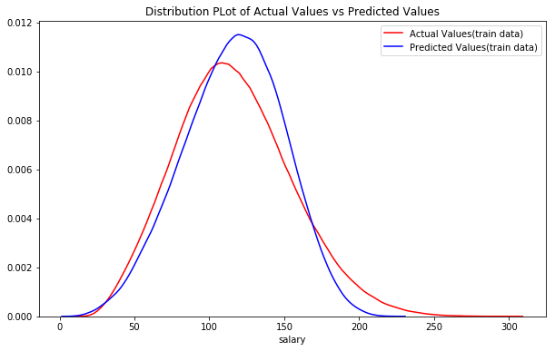

```python
#distribution plot
Title = 'Distribution PLot of Actual Values vs Predicted Values'
dis_data(salary_train, sal_pred, 'Actual Values(train data)', 'Predicted Values(train data)', Title)
```

Ok, so now we can put our test data into the model and see the predictions, It iwll be intreseting to see MSE for the Test dataset.

```python
sal_pred_test = model.predict(feat_test)
print("First five predictions are " , sal_pred_test[0:5])
```

```
First five predictions are  [157.79992676  62.3664856  108.70930481 112.59162903  92.5193634 ]
```

```python
print("Now, the MSE for Test dataset is" , mean_squared_error(salary_test , sal_pred_test))
```

```
Now, the MSE for Test dataset is 384.82988750470025
```

```python
score2 = cross_val_score(model, feat_test, salary_test , cv = 5)
print('5-Cross Validation accuracy', (np.mean(score2)), (np.std(score2)))
```

```
5-Cross Validation accuracy 0.7443984634778346 0.002713859634885687
```

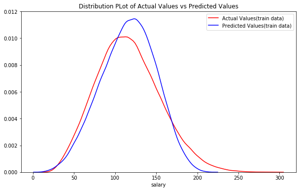

```python
#distribution plot
Title = 'Distribution PLot of Actual Values vs Predicted Values'
dis_data(salary_test, sal_pred_test, 'Actual Values(train data)', 'Predicted Values(train data)', Title)
```

Hence , we need to play with many models , tune the features and try to bring the MSE score below 360

### ---- 6 Hypothesize solution ----

```python
#brainstorm 3 models that you think may improve results over the baseline model based
#on your
```

Brainstorm 3 models that you think may improve results over the baseline model based on your EDA and explain why they're reasonable solutions here.

Also write down any new features that you think you should try adding to the model based on your EDA, e.g. interaction variables, summary statistics for each group, etc

**As per our given Goal, lets try to achieve the MSE less than 360.**

**Three models that may improve results over the baseline model are -**

1. Apply Polynomial Transformation ---> This will create interactive features, which is very helpful in FE.
2. Use Ridge Regression
3. Use Random Forest

## Part 3 - DEVELOP

You will cycle through creating features, tuning models, and training/validing models (steps 7-9) until you've reached your efficacy goal

#### Your metric will be MSE and your goal is:

- <360 for entry-level data science roles
- <320 for senior data science roles

### ---- 7 Engineer features ----

```python
#make sure that data is ready for modeling
#create any new features needed to potentially enhance model
```

### Lets first Understand and look at shape of our working dataset

```python
print('Number of training samples-', feat_train.shape, '\n Features-', feat_train.columns)
print('Number of testing samples-', feat_test.shape, '\n with the features-', feat_test.columns)
print('Number of training salaries-', salary_train.shape)
print('Number of testing salaries-', salary_test.shape)
```

```
Number of training samples- (799996, 31)
 Features- Index(['yearsExperience', 'milesFromMetropolis', 'jobType_CEO', 'jobType_CFO',
       'jobType_CTO', 'jobType_JANITOR', 'jobType_JUNIOR', 'jobType_MANAGER',
       'jobType_SENIOR', 'jobType_VICE_PRESIDENT', 'degree_BACHELORS',
       'degree_DOCTORAL', 'degree_HIGH_SCHOOL', 'degree_MASTERS',
       'degree_NONE', 'major_BIOLOGY', 'major_BUSINESS', 'major_CHEMISTRY',
       'major_COMPSCI', 'major_ENGINEERING', 'major_LITERATURE', 'major_MATH',
       'major_NONE', 'major_PHYSICS', 'industry_AUTO', 'industry_EDUCATION',
       'industry_FINANCE', 'industry_HEALTH', 'industry_OIL',
       'industry_SERVICE', 'industry_WEB'],
      dtype='object')
Number of testing samples- (199999, 31)
 with the features- Index(['yearsExperience', 'milesFromMetropolis', 'jobType_CEO', 'jobType_CFO',
       'jobType_CTO', 'jobType_JANITOR', 'jobType_JUNIOR', 'jobType_MANAGER',
       'jobType_SENIOR', 'jobType_VICE_PRESIDENT', 'degree_BACHELORS',
       'degree_DOCTORAL', 'degree_HIGH_SCHOOL', 'degree_MASTERS',
       'degree_NONE', 'major_BIOLOGY', 'major_BUSINESS', 'major_CHEMISTRY',
       'major_COMPSCI', 'major_ENGINEERING', 'major_LITERATURE', 'major_MATH',
       'major_NONE', 'major_PHYSICS', 'industry_AUTO', 'industry_EDUCATION',
       'industry_FINANCE', 'industry_HEALTH', 'industry_OIL',
       'industry_SERVICE', 'industry_WEB'],
      dtype='object')
Number of training salaries- (799996,)
Number of testing salaries- (199999,)
```

### So, we see that the shape of our dataset is proper in Size, hence we can go ahead

```python
#Lets apply polynomial Features to existing models, to see if they improve further.

pr = PolynomialFeatures(2)
feat_train_pr = pr.fit_transform(feat_train)
feat_test_pr = pr.fit_transform(feat_test)
pr
```

```
PolynomialFeatures(degree=2, include_bias=True, interaction_only=False)
```

```python
## Predict the Train data First again , and see the MSE.
#Create a new model using Polynomial Transformation
poly = LinearRegression()
poly.fit(feat_train_pr, salary_train)
poly_preds = poly.predict(feat_train_pr)
```

```python
#Compare first five predicted values vs actual values -
print ('Predicted Values(train)-', poly_preds[0:5])
print ('Actual Values(train)-', salary_train[0:5].values)
```

```
Predicted Values(train)- [122.87034997 154.66728601  93.94723901 108.47552881 124.42752466]
Actual Values(train)- [ 90 164  87 126 133]
```

```python
# Do it again for Test Data
poly_preds_test = poly.predict(feat_test_pr)
print('First five predictions(train data)-', poly_preds_test[0:5])
#Compare first five predicted values vs actual values -
print ('Predicted Values(train)-', poly_preds_test[0:5])
print ('Actual Values(train)-', salary_test[0:5].values)
```

```
First five predictions(train data)- [159.45600519  60.17805871  96.76041803  99.53565034  93.3278695 ]
Predicted Values(train)- [159.45600519  60.17805871  96.76041803  99.53565034  93.3278695 ]
Actual Values(train)- [186  67  82 104 106]
```

```python
#print R-squared values of training and testing data -
print('R-squared of training data-', poly.score(feat_train_pr, salary_train))
print ('R-squared of testing data-', poly.score(feat_test_pr, salary_test))
```

```
R-squared of training data- 0.7638906678485109
R-squared of testing data- 0.7645098153633604
```

```python
## Lets check same thing for base line models
#print R-squared values of training and testing data -
print ('R-squared of training data-', lm.score(feat_train, salary_train))
print ('R-squared of testing data-', lm.score(feat_test, salary_test))
```

```
R-squared of training data- 0.7433514684842477
R-squared of testing data- 0.744474389633568
```

### So , as compared to Linear Regression with Polynomial Features, we have **0.02** improvement in the R-Squared.

```python
# MSE of Training , and Test Datas
print('MSE OF Training data' ,mean_squared_error(salary_train , poly_preds))
print('MSE of the Test Data set is ',mean_squared_error(salary_test , poly_preds_test))
```

```
MSE OF Training data 353.5169691785272
MSE of the Test Data set is  354.6558841292732
```

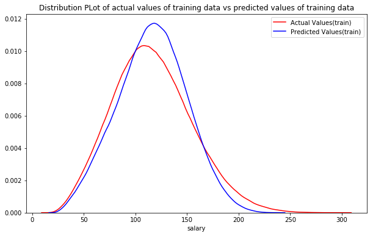

```python
#View distribution plot of actual vs fitted of training data -
dis_data(salary_train, poly_preds, 'Actual Values(train)', 'Predicted Values(train)', title = 'Distribution PLot of actual values of training data vs predicted values of training data')
```

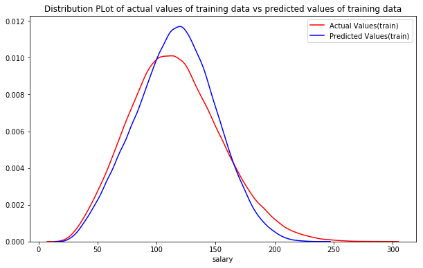

```python
#View distribution plot of actual vs fitted of training data -
dis_data(salary_test, poly_preds_test, 'Actual Values(train)', 'Predicted Values(train)', title = 'Distribution PLot of actual values of training data vs predicted values of training data')
```

### Now lets apply Ridge Regression On Dataset treated with Polynomial Features

```python
## Instantiate a Ridge Regressor and Fit the model to training Data.

RidgeModel = Ridge(alpha=1.0)
RidgeModel.fit(feat_train_pr , salary_train)
```

```
Ridge(alpha=1.0, copy_X=True, fit_intercept=True, max_iter=None,
   normalize=False, random_state=None, solver='auto', tol=0.001)
```

```python
preds_Ridge_train = RidgeModel.predict(feat_train_pr)
preds_Ridge_test = RidgeModel.predict(feat_test_pr)
```

```python
#R-squared of training and testing data -

print('R-squared values(train)-', RidgeModel.score(feat_train_pr, salary_train))
print('R-squared values(test)-', RidgeModel.score(feat_test_pr, salary_test))
```

```
R-squared values(train)- 0.7638922261902712
R-squared values(test)- 0.7645108187953097
```

```python
#MSE of training and testing data -
print('MSE of training data-', mean_squared_error(salary_train, preds_Ridge_train))
print('MSE of testing data-', mean_squared_error(salary_test, preds_Ridge_test))
```

```
MSE of training data- 353.5146359363337
MSE of testing data- 354.6543729280922
```

### After Applying Ridge Regression , we have achieved a MSE of 354 on Training Dataset, which is somewhat Decent.

**We can now use Grid Search to ensure right hyperparameters are used -**

```python
parameters1 = [{'alpha':[0.001,0.1,1, 10, 100, 1000, 10000, 100000, 100000]}]
parameters1
```

```
[{'alpha': [0.001, 0.1, 1, 10, 100, 1000, 10000, 100000, 100000]}]
```

```python
# create a new Regression Object .
RM = Ridge()

#create a gridsearch object and pass RM, parameters1 to it.
Grid = GridSearchCV(RM, parameters1, cv = 5)
# Fit a Grid Model and PAss RM to it.
Grid.fit(feat_train , salary_train)
```

```
GridSearchCV(cv=5, error_score='raise-deprecating',
       estimator=Ridge(alpha=1.0, copy_X=True, fit_intercept=True, max_iter=None,
   normalize=False, random_state=None, solver='auto', tol=0.001),
       fit_params=None, iid='warn', n_jobs=None,
       param_grid=[{'alpha': [0.001, 0.1, 1, 10, 100, 1000, 10000, 100000, 100000]}],
       pre_dispatch='2*n_jobs', refit=True, return_train_score='warn',
       scoring=None, verbose=0)
```

```python
bestRM = Grid.best_estimator_
bestRM
```

```
Ridge(alpha=1, copy_X=True, fit_intercept=True, max_iter=None,
   normalize=False, random_state=None, solver='auto', tol=0.001)
```

```python
bestRM.score(feat_test , salary_test)
```

```
0.744474388773942
```

### Here, we hardly see any imporvement in the Results, hence lets use Random-Forest

```python
#create a random forest object -
RF = RandomForestRegressor(n_estimators = 500, n_jobs = 2, max_features = 14)
```

```python
RF.fit(feat_train , salary_train)
```

```
RandomForestRegressor(bootstrap=True, criterion='mse', max_depth=None,
           max_features=14, max_leaf_nodes=None, min_impurity_decrease=0.0,
           min_impurity_split=None, min_samples_leaf=1,
           min_samples_split=2, min_weight_fraction_leaf=0.0,
           n_estimators=500, n_jobs=2, oob_score=False, random_state=None,
           verbose=0, warm_start=False)
```

```python
preds_RF_test = RF.predict(feat_test)
```

```python
print("R-Squared Error of RF(test) " , RF.score(feat_test , salary_test))
print("Mean Squared Erro RF(test) " , mean_squared_error(salary_test , preds_RF_test))
```

```
R-Squared Error of RF(test)  0.7056218637819769
Mean Squared Erro RF(test)  443.3430562289631
```

**We can Further go ahead and fine tune the Dataset, try to remove noise, try different Log transforming techniques, so that my MSE when Poly, is applied will be much better than this.**

## Completed Below Steps 7-9

### ---- 8 Create models ----

### ---- 9 Test models ----

### ---- 10 Select best model ----

```python
#select the model with the lowest error as your "prodcuction" model
```

## Part 4 - DEPLOY

### ---- 11 Automate pipeline ----

```python
#write script that trains model on entire training set, saves model to disk,
#and scores the "test" dataset
```

```python
#create pipeline for polynomial regression
input = [('scale', StandardScaler()), ('transformation', PolynomialFeatures(include_bias = False)), ('model', LinearRegression())]
pipe = Pipeline(input)
pipe
```

```
Pipeline(memory=None,
     steps=[('scale', StandardScaler(copy=True, with_mean=True, with_std=True)), ('transformation', PolynomialFeatures(degree=2, include_bias=False, interaction_only=False)), ('model', LinearRegression(copy_X=True, fit_intercept=True, n_jobs=None,
         normalize=False))])
```

```python
#fit the pipeline to the entire training data -
polyLRmodel = pipe.fit(features_df, salary_df)
```

```python
#make predictions on the test data and print first five -
preds_pipe = pipe.predict(features_df)
preds_pipe[0:5]
```

```
array([127.1328125, 116.1015625, 135.03125  , 121.15625  , 142.8125   ])
```

```python
## Now lets save the model and we can use it later as well
```

```python
filename = 'Salary_prediction_Linear_model.csv'
joblib.dump(polyLRmodel, filename)
```

```
['Salary_prediction_Linear_model.csv']
```

```python
# Now lets test our own model, by loading it to a variable and use it as required.
loaded_model = joblib.load(filename)
Predictions = loaded_model.score(feat_test , salary_test)
print(Predictions)
```

```
0.7646257502854727
```

### ---- 12 Deploy solution ----

```python
#save your prediction to a csv file or optionally save them as a table in a SQL database
#additionally, you want to save a visualization and summary of your prediction and feature importances
#these visualizations and summaries will be extremely useful to business stakeholders
```

```python
# Now as Suggested, lets test our model on an Unseen data.
test_feat_df = pd.DataFrame(test_feat_df)
#convert data types of the categorical columns of the test data to 'category'-
test_feat_df[['jobId', 'companyId', 'jobType', 'degree', 'major', 'industry']] = test_feat_df[['jobId', 'companyId', 'jobType', 'degree', 'major', 'industry']].astype('category')
print(test_feat_df.dtypes)
#drop features not relevant to salary prediction -
test_feat_df.drop('jobId', axis = 1, inplace = True)
test_feat_df.drop('companyId', axis = 1, inplace = True)

#one_hot_encode the ccategorical data -
test_feat_df = pd.get_dummies(test_feat_df)

#view the top 5 rows of the final data -
test_feat_df.head()
```

```
jobId                  category
companyId              category
jobType                category
degree                 category
major                  category
industry               category
yearsExperience           int64
milesFromMetropolis       int64
dtype: object
```

|  | yearsExperience | milesFromMetropolis | jobType_CEO | jobType_CFO | jobType_CTO | jobType_JANITOR | jobType_JUNIOR | jobType_MANAGER | jobType_SENIOR | jobType_VICE_PRESIDENT | ... | major_MATH | major_NONE | major_PHYSICS | industry_AUTO | industry_EDUCATION | industry_FINANCE | industry_HEALTH | industry_OIL | industry_SERVICE | industry_WEB |
| --- | --- | --- | --- | --- | --- | --- | --- | --- | --- | --- | --- | --- | --- | --- | --- | --- | --- | --- | --- | --- | --- |
| 0 | 22 | 73 | 0 | 0 | 0 | 0 | 0 | 1 | 0 | 0 | ... | 0 | 1 | 0 | 0 | 0 | 0 | 1 | 0 | 0 | 0 |
| 1 | 20 | 47 | 0 | 0 | 0 | 0 | 1 | 0 | 0 | 0 | ... | 0 | 1 | 0 | 1 | 0 | 0 | 0 | 0 | 0 | 0 |
| 2 | 17 | 9 | 0 | 0 | 1 | 0 | 0 | 0 | 0 | 0 | ... | 0 | 0 | 0 | 0 | 0 | 0 | 1 | 0 | 0 | 0 |
| 3 | 14 | 96 | 0 | 0 | 0 | 0 | 0 | 1 | 0 | 0 | ... | 0 | 1 | 0 | 0 | 0 | 0 | 0 | 1 | 0 | 0 |
| 4 | 10 | 44 | 0 | 0 | 0 | 0 | 1 | 0 | 0 | 0 | ... | 0 | 0 | 0 | 0 | 0 | 0 | 0 | 1 | 0 | 0 |

5 rows × 31 columns

**After doing all this cleansing of the data, test data is ready to be used as an input to the saved linear regression model so that salaries can be predicted. WE can consider this test data as real world data for whom salaries need to be predicted.**

```python
#Predict -
prediction = loaded_model.predict(test_feat_df)
prediction[0:5]
```

[output not shown]

```python
## Now Lets check  the important Features in the dataset.

if hasattr(loaded_model, 'feature_importances_'):
    importances = loaded_model.feature_importances_
else:
    #linear models don't have feature importances
    importances = [0]*len(feat_test.columns)

feature_importances = pd.DataFrame({'feature':feat_test.columns, 'importance':importances})
feature_importances.sort_values(by = 'importance', ascending = False, inplace = True )

#set index to feature -
feature_importances.set_index('feature', inplace = True, drop = True)
```

```python
feature_importances.head()
```

| feature | importance |
| --- | --- |
| yearsExperience | 0 |
| major_BUSINESS | 0 |
| industry_SERVICE | 0 |
| industry_OIL | 0 |
| industry_HEALTH | 0 |

### **SUMMARY**

**Applying second order polynomial transformation to the features gave the most accurate prediction with the least error when using a Linear Regression Model. The result was a mean squared error of 354 with the accuracy of 76%.**

### ---- 13 Measure efficacy ----

We'll skip this step since we don't have the outcomes for the test data